# Uso de R en experimentación animal:

Mapas con R

Edimer David Jaramillo

27/1/2021

# Mapas desde R

## Descarga de mapas

- Utilizamos la biblioteca `raster`
- Para descargar [*shapes*](https://es.wikipedia.org/wiki/Shapefile) podemos utilizar la función `getData()`
- El siguiente código permite ver los nombres con codificación ISO para cada país, en este caso para Colombia el nombre es **COL**.

```r
library(raster)
getData(name = "ISO3")
```

| ISO3 | NAME |
| --- | --- |
| AFG | Afghanistan |
| XAD | Akrotiri and Dhekelia |
| ALA | Åland |
| ALB | Albania |
| DZA | Algeria |
| ASM | American Samoa |
| AND | Andorra |
| AGO | Angola |
| AIA | Anguilla |
| ATA | Antarctica |

[output cut: 246 more lines]

- **Obtención de datos con función getData() para Colombia:**
  - `level = 0`: división a nivel de país.
  - `level = 1`: división regional (departamentos)
  - `level = 2`: división municipal (municipios)

```r
colombia_pais <- getData(name = "GADM", country = "COL", level = 0)
colombia_dept <- getData(name = "GADM", country = "COL", level = 1)
colombia_muni <- getData(name = "GADM", country = "COL", level = 2)
```

- Ahora podemos graficar cada mapa a través de la función `plot()`:

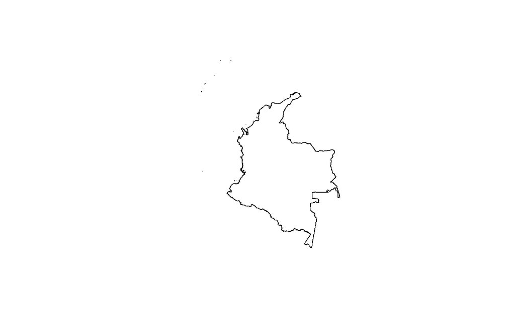

```r
plot(colombia_pais)
```

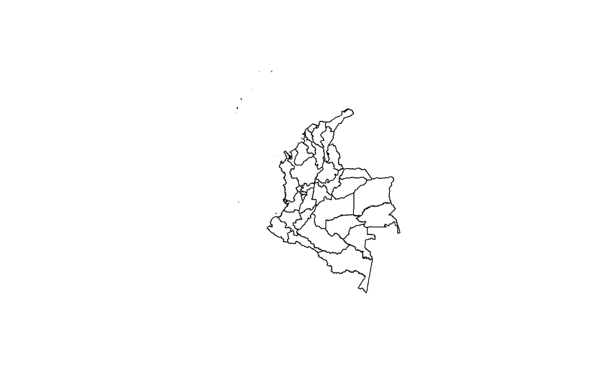

```r
plot(colombia_dept)
```

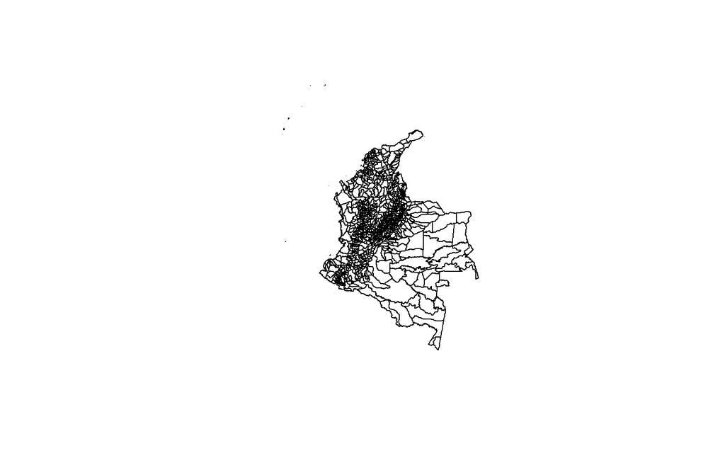

```r
plot(colombia_muni)
```

- Los objetos previamente creados son de tipo `SpatialPolygonsDataFrame`:

```r
class(colombia_pais)
```

```
## [1] "SpatialPolygonsDataFrame"
## attr(,"package")
## [1] "sp"
```

- Podemos acceder a los nombres de cada departamento de la siguiente manera:

```r
colombia_dept$NAME_1
```

```
##  [1] "Amazonas"                 "Antioquia"
##  [3] "Arauca"                   "Atlántico"
##  [5] "Bolívar"                  "Boyacá"
##  [7] "Caldas"                   "Caquetá"
##  [9] "Casanare"                 "Cauca"
## [11] "Cesar"                    "Chocó"
## [13] "Córdoba"                  "Cundinamarca"
## [15] "Guainía"                  "Guaviare"
## [17] "Huila"                    "La Guajira"
## [19] "Magdalena"                "Meta"
## [21] "Nariño"                   "Norte de Santander"
## [23] "Putumayo"                 "Quindío"
## [25] "Risaralda"                "San Andrés y Providencia"
## [27] "Santander"                "Sucre"
## [29] "Tolima"                   "Valle del Cauca"
## [31] "Vaupés"                   "Vichada"
```

## Biblioteca `rworldxtra`

- La biblioteca `rworldxtra` posee mapas con información de interés, por ejemplo, la población mundial. Cargamos el conjunto de datos `countriesHigh` que es de tipo `SpatialPolygonsDataFrame`.

```r
library(rworldxtra)
data("countriesHigh")

class(countriesHigh)
```

```
## [1] "SpatialPolygonsDataFrame"
## attr(,"package")
## [1] "sp"
```

- Graficamos con la función `plot()`:

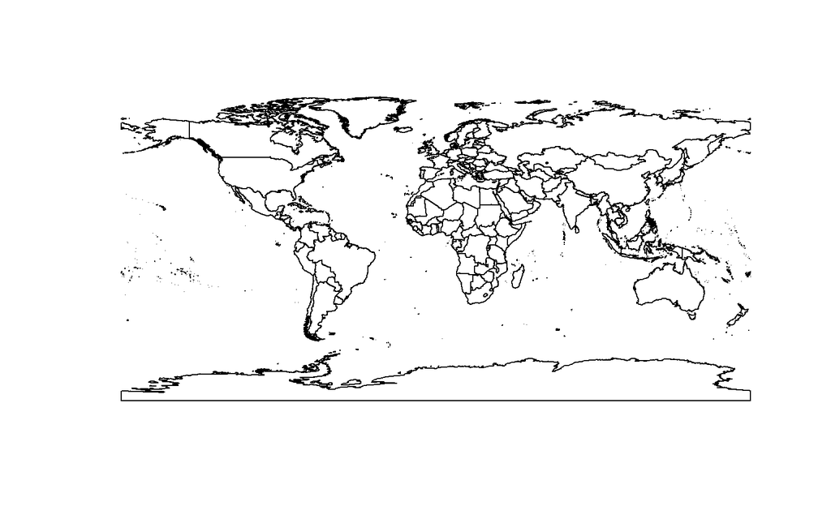

```r
plot(countriesHigh)
```

# Biblioteca `sf`

- A través de la biblioteca `sf` podemos convertir los objetos de tipo `SpatialPolygonsDataFrame` a `data.frame`, facilitando el manejo con bibliotecas como `dplyr` o la visualización con `ggplot2`.
- La función `st_as_sf()` recibe un objeto de tipo `SpatialPolygonsDataFrame` y realiza la conversión a `data.frame`.
- En la variable mundo estamos asignando el objeto `countriesHigh` que habíamos cargado previamente. Cuando consultamos la clase vemos que es de tipo `data.frame` y `sf`.

```r
library(sf)
mundo <- st_as_sf(countriesHigh)
class(mundo)
```

```
## [1] "sf"         "data.frame"
```

- Veamos el objeto `mundo` como `data.frame()`:

```r
mundo %>% as.data.frame()
```

| ne_10m_adm | ScaleRank | LabelRank | FeatureCla | OID_ | SOVEREIGNT | SOV_A3 | ADM0_DIF | LEVEL | TYPE | ADMIN | ADM0_A3 | GEOU_DIF | GEOUNIT | GU_A3 | SU_DIF | SUBUNIT | SU_A3 | NAME | ABBREV | POSTAL | NAME_FORMA | TERR_ | NAME_SORT | MAP_COLOR | POP_EST | GDP_MD_EST | FIPS_10_ | ISO_A2 | ISO_A3 | … |
| --- | --- | --- | --- | --- | --- | --- | --- | --- | --- | --- | --- | --- | --- | --- | --- | --- | --- | --- | --- | --- | --- | --- | --- | --- | --- | --- | --- | --- | --- | --- |
| ABW | 3 | 6 | Adm-0 country | 18 | Netherlands | NL1 | 1 | 2 | Country | Aruba | ABW | 0 | Aruba | ABW | 0 | Aruba | ABW | Aruba | Aruba | AW | NA | Neth. | Aruba | 9 | 103065 | 2.258e+03 | 0 | AW | ABW | … |
| AFG | 1 | 2 | Adm-0 country | 78 | Afghanistan | AFG | 0 | 2 | Sovereign country | Afghanistan | AFG | 0 | Afghanistan | AFG | 0 | Afghanistan | AFG | Afghanistan | Afg. | AF | Islamic State of Afghanistan | NA | Afghanistan | 7 | 28400000 | 2.227e+04 | 0 | AF | AFG | … |
| AGO | 1 | 2 | Adm-0 country | 82 | Angola | AGO | 0 | 2 | Sovereign country | Angola | AGO | 0 | Angola | AGO | 0 | Angola | AGO | Angola | Ang. | AO | Republic of Angola | NA | Angola | 1 | 12799293 | 1.103e+05 | 0 | AO | AGO | … |
| AIA | 1 | 8 | Adm-0 country | 48 | United Kingdom | GB1 | 1 | 2 | Dependency | Anguilla | AIA | 0 | Anguilla | AIA | 0 | Anguilla | AIA | Anguilla | Ang. | AI | NA | U.K. | Anguilla | 3 | 14436 | 1.089e+02 | 0 | AI | AIA | … |
| ALB | 1 | 5 | Adm-0 country | 79 | Albania | ALB | 0 | 2 | Sovereign country | Albania | ALB | 0 | Albania | ALB | 0 | Albania | ALB | Albania | Alb. | AL | Republic of Albania | NA | Albania | 6 | 3639453 | 2.181e+04 | 0 | AL | ALB | … |
| ALD | 1 | 7 | Adm-0 country | 16 | Finland | FI1 | 1 | 2 | Country | Aland | ALD | 0 | Aland | ALD | 0 | Aland | ALD | Aland | Aland | AI | Eland Islands | Fin. | Aland | 6 | 27153 | -9.900e+01 | -99 | -99 | ALA | … |
| AND | 3 | 5 | Adm-0 country | 81 | Andorra | AND | 0 | 2 | Sovereign country | Andorra | AND | 0 | Andorra | AND | 0 | Andorra | AND | Andorra | And. | AND | Principality of Andorra | NA | Andorra | 8 | 83888 | 3.660e+03 | 0 | AD | AND | … |
| ARE | 1 | 2 | Adm-0 country | 255 | United Arab Emirates | ARE | 0 | 2 | Sovereign country | United Arab Emirates | ARE | 0 | United Arab Emirates | ARE | 0 | United Arab Emirates | ARE | United Arab Emirates | U.A.E. | AE | NA | NA | United Arab Emirates | 3 | 4798491 | 1.843e+05 | 0 | AE | ARE | … |
| ARG | 1 | 2 | Adm-0 country | 84 | Argentina | ARG | 0 | 2 | Sovereign country | Argentina | ARG | 0 | Argentina | ARG | 0 | Argentina | ARG | Argentina | Arg. | AR | Argentine Republic | NA | Argentina | 13 | 40913584 | 5.739e+05 | 0 | AR | ARG | … |
| ARM | 1 | 2 | Adm-0 country | 85 | Armenia | ARM | 0 | 2 | Sovereign country | Armenia | ARM | 0 | Armenia | ARM | 0 | Armenia | ARM | Armenia | Arm. | ARM | Republic of Armenia | NA | Armenia | 10 | 2967004 | 1.877e+04 | 0 | AM | ARM | … |

[output cut: 243 more lines]

## Población mundial

- Ahora podemos graficar la población mundial (`POP_EST`) con `ggplot2` haciendo uso del objeto geométrico `geom_sf()`:

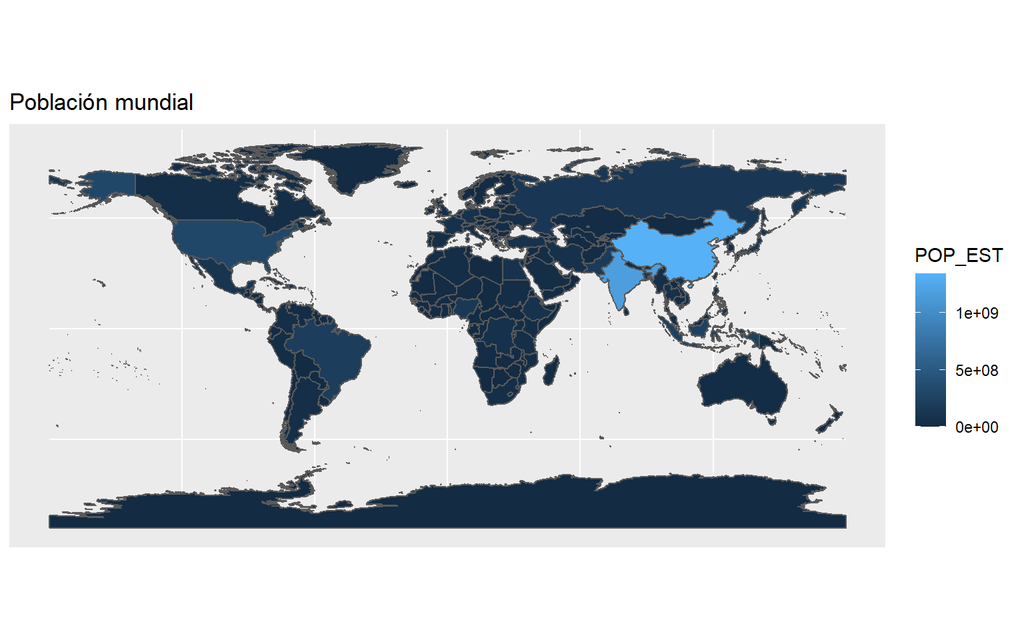

```r
library(ggplot2)
mundo %>%
  ggplot(aes(fill = POP_EST)) +
  geom_sf() +
  labs(title = "Población mundial")
```

## Sur América y el Caribe

- Podemos filtrar sólo Sur América y el Caribe para ejemplificar cómo usar las funciones de `dplyr`. Además le asignamos colores diferentes con la biblioteca `viridis`.

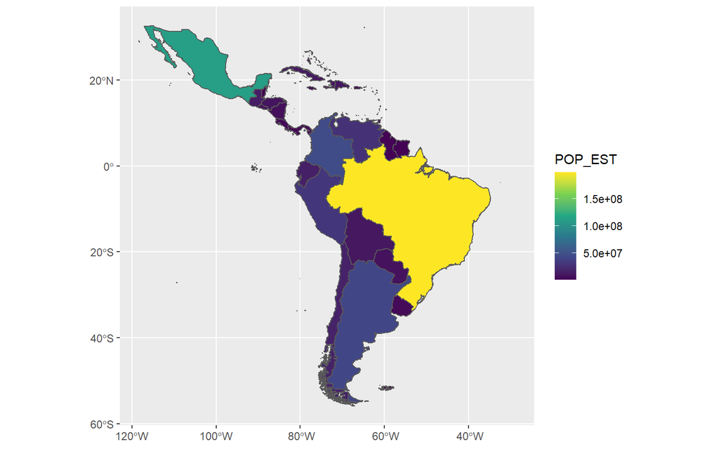

```r
library(viridis)
library(dplyr)
mundo %>%
  filter(continent == "South America and the Caribbean") %>%
  ggplot(aes(fill = POP_EST)) +
  geom_sf() +
  scale_fill_viridis_c()
```

## Antioquia

- Podemos convertir los datos de Colombia a tipo `sf` o `data.frame`:

```r
municipios_df <- st_as_sf(colombia_muni)
municipios_df %>% as.data.frame()
```

|  | GID_0 | NAME_0 | GID_1 | NAME_1 | NL_NAME_1 | GID_2 | NAME_2 | VARNAME_2 | NL_NAME_2 | TYPE_2 | ENGTYPE_2 | CC_2 | HASC_2 | geometry |
| --- | --- | --- | --- | --- | --- | --- | --- | --- | --- | --- | --- | --- | --- | --- |
| 15629 | COL | Colombia | COL.1_1 | Amazonas | NA | COL.1.1_1 | El Encanto | NA | NA | Corregimiento Departamento | Corregimiento Departamento | NA | CO.AM.EE |  |
| 15634 | COL | Colombia | COL.1_1 | Amazonas | NA | COL.1.2_1 | La Chorrera | NA | NA | Corregimiento Departamento | Corregimiento Departamento | NA | CO.AM.LC |  |
| 15699 | COL | Colombia | COL.1_1 | Amazonas | NA | COL.1.3_1 | La Pedrera | NA | NA | Corregimiento Departamento | Corregimiento Departamento | NA | CO.AM.LP |  |
| 16578 | COL | Colombia | COL.1_1 | Amazonas | NA | COL.1.4_1 | Leticia | NA | NA | Municipio | Municipality | NA | CO.AM.LE |  |
| 15505 | COL | Colombia | COL.1_1 | Amazonas | NA | COL.1.5_1 | Mirití-Paraná | Miriti Parana | NA | Corregimiento Departamento | Corregimiento Departamento | NA | CO.AM.MI |  |
| 16577 | COL | Colombia | COL.1_1 | Amazonas | NA | COL.1.6_1 | Puerto Nariño | NA | NA | Municipio | Municipality | NA | CO.AM.PN |  |
| 15494 | COL | Colombia | COL.1_1 | Amazonas | NA | COL.1.7_1 | Puerto Santander | NA | NA | Corregimiento Departamento | Corregimiento Departamento | NA | CO.AM.PS |  |
| 16055 | COL | Colombia | COL.1_1 | Amazonas | NA | COL.1.8_1 | Tarapacá | NA | NA | Corregimiento Departamento | Corregimiento Departamento | NA | CO.AM.TA |  |
| 14570 | COL | Colombia | COL.2_1 | Antioquia | NA | COL.2.1_1 | Abejorral | NA | NA | Municipio | Municipality | NA | CO.AN.AB |  |
| 14343 | COL | Colombia | COL.2_1 | Antioquia | NA | COL.2.2_1 | Abriaquí | NA | NA | Municipio | Municipality | NA | CO.AN.AQ |  |

[output cut: 1055 more lines]

- Filtramos sólo el departamento de Antioquia y graficamos:

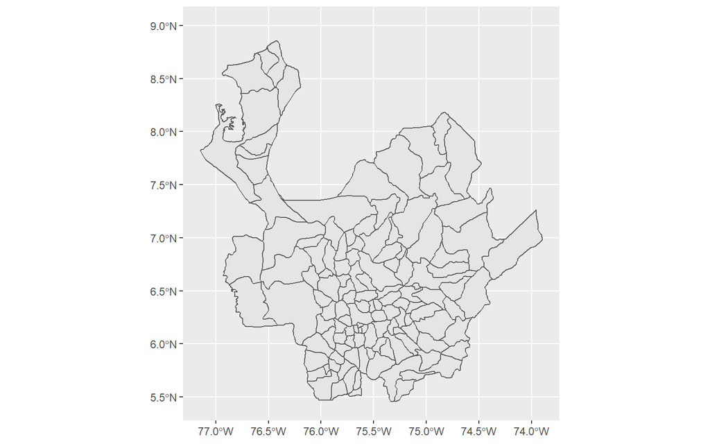

```r
municipios_df %>%
  filter(NAME_1 == "Antioquia") %>%
  ggplot() +
  geom_sf()
```

## Cundinamarca

- Filtramos sólo el departamento de Cundinamarca y graficamos:

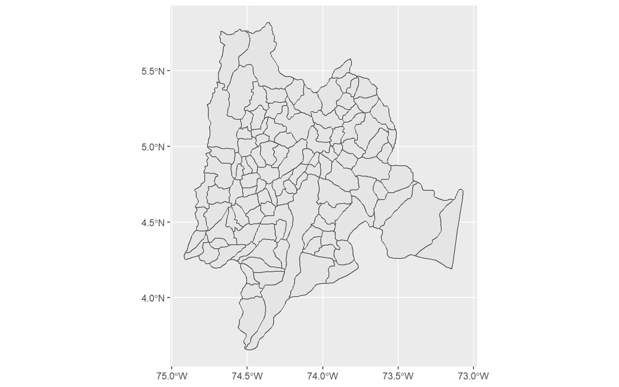

```r
municipios_df %>%
  filter(NAME_1 == "Cundinamarca") %>%
  ggplot() +
  geom_sf()
```

# Mapa COVID Colombia

## Descargar datos COVID

- Descargas datos actualizados por departamento desde [ESRI.](https://datosabiertos.esri.co/datasets/colombia-covid19-coronavirus-departamento)
- 1. Dar clic en descargar:

[figure not shown]

- 2. Seleccionar la opción *Hoja de Cálculo*:

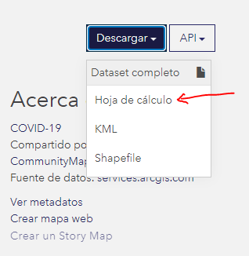

```r
library(readr)
library(janitor)
covid_deptos <- read_csv("data/Colombia_COVID19_Coronavirus_Departamento.csv") %>%
  clean_names()
covid_deptos
```

| objectid | dpto | nombre_dpt | coronavirus | casos_confirmados | global_id | shape_area | shape_length |
| --- | --- | --- | --- | --- | --- | --- | --- |
| 198 | 05 | ANTIOQUIA | SI | 320219 | a2ceb168-ae6e-4c60-a408-812a79715157 | 62804723660 | 2371289.41 |
| 199 | 08 | ATLÁNTICO | SI | 44141 | 518cc0f9-f7fe-47af-8bba-9a6e05cccbe2 | 3315729487 | 279792.14 |
| 200 | 11 | BOGOTÁ, D.C. | SI | 598993 | 242c72a5-dc3a-48ab-9dbf-41f8b26c84df | 1622861966 | 416463.37 |
| 201 | 13 | BOLÍVAR | SI | 9411 | a776cac8-265d-4484-b53b-491f639f5592 | 26714544669 | 1734136.68 |
| 202 | 15 | BOYACÁ | SI | 39882 | 2d71e8cb-4321-4d2e-be6e-cc716578cb55 | 23138174497 | 1760491.33 |
| 203 | 17 | CALDAS | SI | 42853 | 2a5be55f-dd03-4f0f-bc00-1739a1538080 | 7425282088 | 737100.40 |
| 204 | 18 | CAQUETÁ | SI | 16324 | 3f929a8a-968b-4187-ac14-9a9bd0424b02 | 90104119701 | 2373598.76 |
| 205 | 19 | CAUCA | SI | 24799 | f0472340-a02e-4ec5-a5ba-b71d07856bbb | 31243062737 | 1548896.87 |
| 206 | 20 | CESAR | SI | 37637 | f9c007e4-ffc1-48d1-a34e-f5e79a963ef0 | 22562318442 | 1389969.57 |
| 207 | 23 | CÓRDOBA | SI | 32138 | 413e0d8b-cdcf-4869-bd7b-e3a277246bd9 | 25086353002 | 1069949.56 |

[output cut: 23 more lines]

## Unión de datos

- Vamos a unir los datos que descargamos previamente con la función `getData()` con la información de casos confirmados de Coronavirus por departamento. Cambiamos el nombre de la variable que contiene información del departamento para poder unirla con los datos del Coronavirus.

```r
datos_deptos <- st_as_sf(colombia_dept) %>%
  rename(nombre_dpt = NAME_1)
datos_deptos %>% as.data.frame()
```

|  | GID_0 | NAME_0 | GID_1 | nombre_dpt | VARNAME_1 | NL_NAME_1 | TYPE_1 | ENGTYPE_1 | CC_1 | HASC_1 | geometry |
| --- | --- | --- | --- | --- | --- | --- | --- | --- | --- | --- | --- |
| 1 | COL | Colombia | COL.1_1 | Amazonas | NA | NA | Comisaría | Commissiary | NA | CO.AM |  |
| 12 | COL | Colombia | COL.2_1 | Antioquia | NA | NA | Departamento | Department | NA | CO.AN |  |
| 23 | COL | Colombia | COL.3_1 | Arauca | NA | NA | Intendencia | Intendancy | NA | CO.AR |  |
| 27 | COL | Colombia | COL.4_1 | Atlántico | NA | NA | Departamento | Department | NA | CO.AT |  |
| 28 | COL | Colombia | COL.5_1 | Bolívar | NA | NA | Departamento | Department | NA | CO.BL |  |
| 29 | COL | Colombia | COL.6_1 | Boyacá | NA | NA | Departamento | Department | NA | CO.BY |  |
| 30 | COL | Colombia | COL.7_1 | Caldas | NA | NA | Departamento | Department | NA | CO.CL |  |
| 31 | COL | Colombia | COL.8_1 | Caquetá | NA | NA | Intendencia | Intendancy | NA | CO.CQ |  |
| 32 | COL | Colombia | COL.9_1 | Casanare | NA | NA | Intendencia | Intendancy | NA | CO.CS |  |
| 2 | COL | Colombia | COL.10_1 | Cauca | NA | NA | Departamento | Department | NA | CO.CA |  |

[output cut: 22 more lines]

- Como los nombres de los departamentos en la base de datos del Coronavirus están en mayúscula los pasamos a minúscula con la primera letra en mayúscula, así quedarán igual a la base de datos que contiene el mapa de Colombia por departamentos.
- Vemos que la base de datos del Coronavirus tiene a Bogotá como departamento aislado de Cundinamarca, sin embargo, en la base de datos de los departamentos está incluido en Cundinamarca, por esta razón sumamos los de Bogotá (total 598993) a Cundinamarca. Cundinamarca tenía para el 27 de enero de 2021 91320 más 598993 de Bogotá, queda al final con 690313 casos confirmado.
- Cambiamos el nombre de “Archipiélago de san andrés, providencia y santa catalina” a “San Andrés y Providencia” para que coincida en las dos bases de datos.
- Cambiamos el nombre de “Norte de santander” a “Norte de Santander” (S mayúscula) para que coincida en las dos bases de datos.
- Cambiamos el nombre de “Valle del cauca” a “Valle del cauca” (C mayúscula) para que coincida en las dos bases de datos.
- Cambiamos el nombre de “La guajira” a “La Guajira” (G mayúscula) para que coincida en las dos bases de datos.
- Finalmente eliminamos la fila que corresponde a Bogotá y Seleccionamos sólo la columna del nombre del departamento y los casos confirmados.

```r
library(Hmisc)
covid_deptos2 <- covid_deptos %>%
  mutate(nombre_dpt = capitalize(tolower(nombre_dpt)),
         casos_confirmados = if_else(nombre_dpt == "Cundinamarca",
                                     true = casos_confirmados + 598993,
                                     false = casos_confirmados),
         nombre_dpt = gsub("Archipiélago de san andrés, providencia y santa catalina",
                           "San Andrés y Providencia",
                           nombre_dpt),
         nombre_dpt = gsub("Norte de santander",
                           "Norte de Santander",
                           nombre_dpt),
         nombre_dpt = gsub("Valle del cauca",
                           "Valle del Cauca",
                           nombre_dpt),
         nombre_dpt = gsub("La guajira",
                           "La Guajira",
                           nombre_dpt)) %>%
  filter(nombre_dpt != "Bogotá, d.c.") %>%
  select(nombre_dpt, casos_confirmados)
covid_deptos2
```

| nombre_dpt | casos_confirmados |
| --- | --- |
| Antioquia | 320219 |
| Atlántico | 44141 |
| Bolívar | 9411 |
| Boyacá | 39882 |
| Caldas | 42853 |
| Caquetá | 16324 |
| Cauca | 24799 |
| Cesar | 37637 |
| Córdoba | 32138 |
| Cundinamarca | 690313 |

[output cut: 22 more lines]

- Unión de datos del mapa por departamentos y casos confirmados de Coronavirus:

```r
df_mapa_covid <- inner_join(datos_deptos, covid_deptos2, by = "nombre_dpt")
df_mapa_covid %>% as.data.frame()
```

| GID_0 | NAME_0 | GID_1 | nombre_dpt | VARNAME_1 | NL_NAME_1 | TYPE_1 | ENGTYPE_1 | CC_1 | HASC_1 | casos_confirmados | geometry |
| --- | --- | --- | --- | --- | --- | --- | --- | --- | --- | --- | --- |
| COL | Colombia | COL.1_1 | Amazonas | NA | NA | Comisaría | Commissiary | NA | CO.AM | 3553 |  |
| COL | Colombia | COL.2_1 | Antioquia | NA | NA | Departamento | Department | NA | CO.AN | 320219 |  |
| COL | Colombia | COL.3_1 | Arauca | NA | NA | Intendencia | Intendancy | NA | CO.AR | 5225 |  |
| COL | Colombia | COL.4_1 | Atlántico | NA | NA | Departamento | Department | NA | CO.AT | 44141 |  |
| COL | Colombia | COL.5_1 | Bolívar | NA | NA | Departamento | Department | NA | CO.BL | 9411 |  |
| COL | Colombia | COL.6_1 | Boyacá | NA | NA | Departamento | Department | NA | CO.BY | 39882 |  |
| COL | Colombia | COL.7_1 | Caldas | NA | NA | Departamento | Department | NA | CO.CL | 42853 |  |
| COL | Colombia | COL.8_1 | Caquetá | NA | NA | Intendencia | Intendancy | NA | CO.CQ | 16324 |  |
| COL | Colombia | COL.9_1 | Casanare | NA | NA | Intendencia | Intendancy | NA | CO.CS | 11089 |  |
| COL | Colombia | COL.10_1 | Cauca | NA | NA | Departamento | Department | NA | CO.CA | 24799 |  |

[output cut: 22 more lines]

## Covid Departamentos

- Primer mapa:

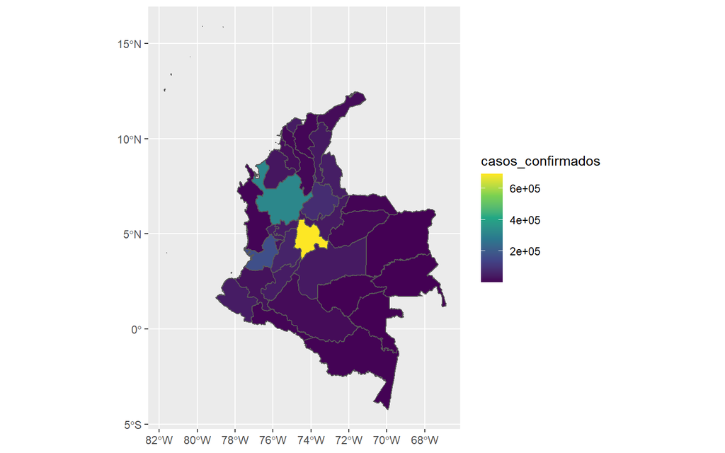

```r
df_mapa_covid %>%
  ggplot(aes(fill = casos_confirmados)) +
  geom_sf() +
  scale_fill_viridis_c()
```

- Mejorando la estética del mapa anterior:

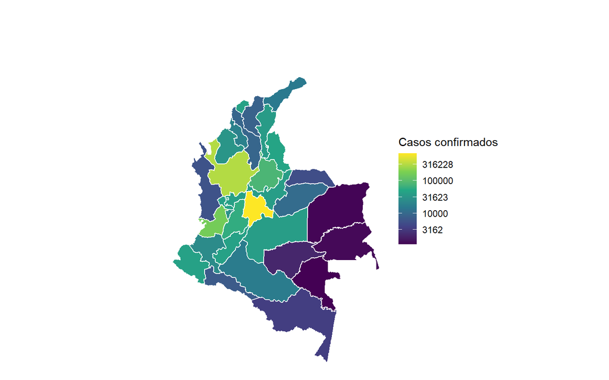

```r
library(scales)
df_mapa_covid %>%
  ggplot(aes(fill = casos_confirmados)) +
  geom_sf(color = "white") +
  scale_fill_viridis_c(
    trans = "log10",
    breaks = trans_breaks("log10",
                          function(x)
                            round(10 ^ x, digits = 0))
  ) +
  labs(fill = "Casos confirmados") +
  theme_void()
```

- Cambiando los colores:

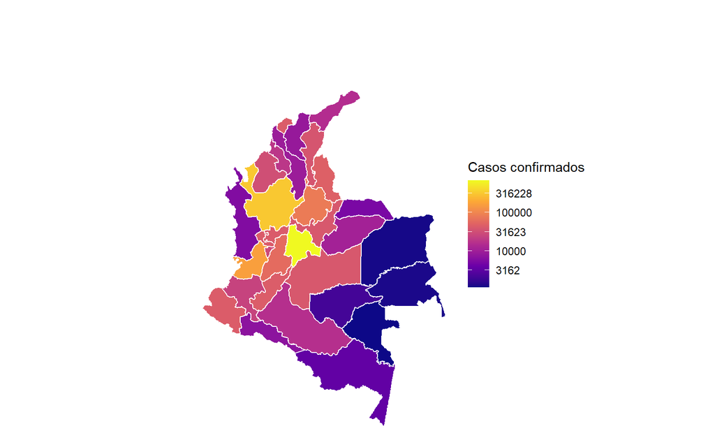

```r
library(scales)
df_mapa_covid %>%
  ggplot(aes(fill = casos_confirmados)) +
  geom_sf(color = "white") +
  scale_fill_viridis_c(
    option = "C",
    trans = "log10",
    breaks = trans_breaks("log10",
                          function(x)
                            round(10 ^ x, digits = 0))
  ) +
  labs(fill = "Casos confirmados") +
  theme_void()
```

## *Shape* Covid

- En los ejemplos previos juntamos las bases de datos de los mapas y los casos del Coronavirus, sin embargo, podemos [descargar](https://datosabiertos.esri.co/datasets/colombia-covid19-coronavirus-departamento) directamente el archivo *shape* de Coronavirus por departamentos en Colombia y graficarlo.
- 1. Dar clic en descargar:

[figure not shown]

- 2. Seleccionar la opción *Shapefile*:

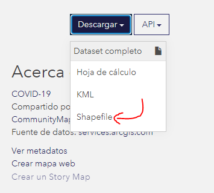

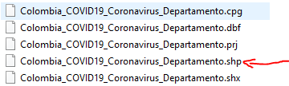

- 5. Lectura de datos descargados y conversión a tipo `sf`:

```r
shape_covid <- read_sf("data/Colombia_COVID19_Coronavirus_Departamento.shp")
shape_covid
```

| OBJECTID | DPTO | NOMBRE_DPT | Coronaviru | Casos_Conf | GlobalID | Shape__Are | Shape__Len | geometry |
| --- | --- | --- | --- | --- | --- | --- | --- | --- |
| 198 | 05 | ANTIOQUIA | SI | 319066 | a2ceb168-ae6e-4c60-a408-812a79715157 | 62804723660 | 2371289.41 |  |
| 199 | 08 | ATLÁNTICO | SI | 43841 | 518cc0f9-f7fe-47af-8bba-9a6e05cccbe2 | 3315729487 | 279792.14 |  |
| 200 | 11 | BOGOTÁ, D.C. | SI | 595731 | 242c72a5-dc3a-48ab-9dbf-41f8b26c84df | 1622861966 | 416463.37 |  |
| 201 | 13 | BOLÍVAR | SI | 9367 | a776cac8-265d-4484-b53b-491f639f5592 | 26714544669 | 1734136.68 |  |
| 202 | 15 | BOYACÁ | SI | 39477 | 2d71e8cb-4321-4d2e-be6e-cc716578cb55 | 23138174497 | 1760491.33 |  |
| 203 | 17 | CALDAS | SI | 42420 | 2a5be55f-dd03-4f0f-bc00-1739a1538080 | 7425282088 | 737100.40 |  |
| 204 | 18 | CAQUETÁ | SI | 16262 | 3f929a8a-968b-4187-ac14-9a9bd0424b02 | 90104119701 | 2373598.76 |  |
| 205 | 19 | CAUCA | SI | 24451 | f0472340-a02e-4ec5-a5ba-b71d07856bbb | 31243062737 | 1548896.87 |  |
| 206 | 20 | CESAR | SI | 37519 | f9c007e4-ffc1-48d1-a34e-f5e79a963ef0 | 22562318442 | 1389969.57 |  |
| 207 | 23 | CÓRDOBA | SI | 31957 | 413e0d8b-cdcf-4869-bd7b-e3a277246bd9 | 25086353002 | 1069949.56 |  |

[output cut: 23 more lines]

- Mapa:

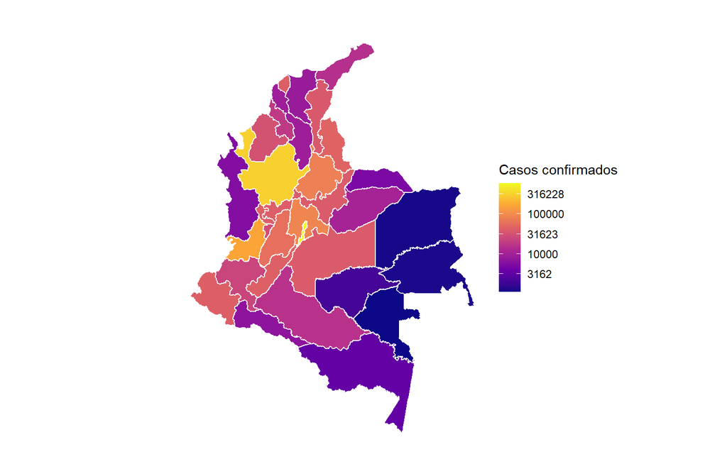

```r
shape_covid %>%
  ggplot(aes(fill = Casos_Conf)) +
  geom_sf(color = "white") +
  scale_fill_viridis_c(
    option = "C",
    trans = "log10",
    breaks = trans_breaks("log10",
                          function(x)
                            round(10 ^ x, digits = 0))
  ) +
  labs(fill = "Casos confirmados") +
  theme_void()
```